# Statistical observable analysis for FX correlation matrices

# Correlation Elements

## Example correlations

Reproduces figure 1 in the article with date range set to 2020-04-01 to 2022-01-31 (time_range_type = “in-sample”) and time_scale = “5 minutes”.

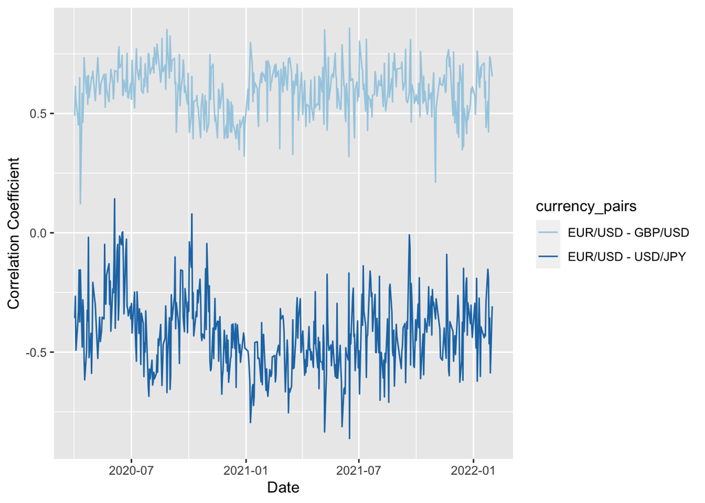

# Statistical Summary of Observables

## Individual Distributions

Reproduces figure 2 in the article with date range set to 2020-04-01 to 2022-01-31 (time_range_type = “in-sample”) and time_scale = “5 minutes”.

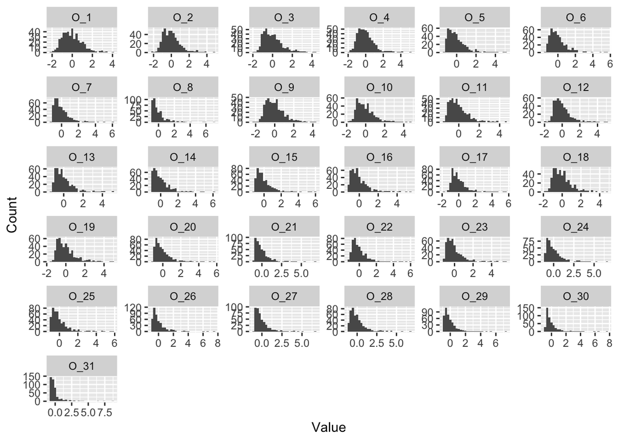

## Correlation of Observables

Reproduces figure 3 in the article with date range set to 2020-04-01 to 2022-01-31 (time_range_type = “in-sample”) and time_scale = “5 minutes”.

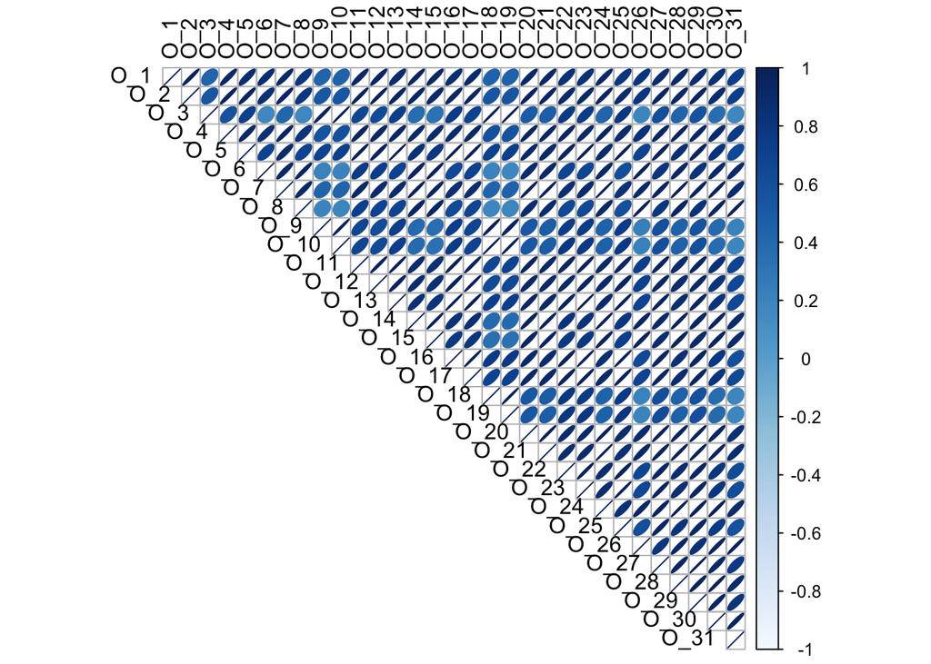

# Anomaly Detection

## Observable Vector Length Euclidean Metric

Top 10 Deviation vector lengths

| date | vector_length_from_center | description |
| --- | --- | --- |
| 2020-06-04 | 335.49 | ECB Press Conference |
| 2020-06-12 | 307.51 | NA |
| 2020-06-15 | 219.02 | NA |
| 2020-06-16 | 215.49 | BoJ Press Conference |
| 2020-06-16 | 215.49 | BoE MPC Vote Rate Unchanged |
| 2020-06-16 | 215.49 | BoE MPC Vote Rate Cut |
| 2020-06-23 | 178.69 | NA |
| 2020-06-09 | 173.76 | NA |
| 2020-06-17 | 136.50 | NA |
| 2020-06-22 | 128.58 | PBoC Interest Rate Decision |

## Observable Vector Length Mahalanobis Metric

Top 10 Deviation vector lengths

| date | vector_length_from_center | description |
| --- | --- | --- |
| 2021-06-16 | 334.89 | FOMC Press Conference |
| 2020-06-04 | 186.57 | ECB Press Conference |
| 2020-06-12 | 118.79 | NA |
| 2020-06-16 | 96.13 | BoJ Press Conference |
| 2020-06-16 | 96.13 | BoE MPC Vote Rate Unchanged |
| 2020-06-16 | 96.13 | BoE MPC Vote Rate Cut |
| 2021-10-21 | 91.91 | European Council Meeting |
| 2020-10-06 | 89.64 | NA |
| 2021-06-04 | 88.25 | Nonfarm Payrolls |
| 2021-05-07 | 77.96 | Nonfarm Payrolls |

## Raw Correlation Vector Length Euclidean Metric

Top 10 Deviation vector lengths

| date | vector_length_from_center | description |
| --- | --- | --- |
| 2021-11-01 | 997.34 | NA |
| 2021-06-16 | 806.86 | FOMC Press Conference |
| 2020-04-10 | 774.25 | Consumer Price Index ex Food & Energy (MoM) |
| 2020-04-10 | 774.25 | Consumer Price Index ex Food & Energy (YoY) |
| 2021-05-07 | 728.57 | Nonfarm Payrolls |
| 2020-06-16 | 571.75 | BoJ Press Conference |
| 2020-06-16 | 571.75 | BoE MPC Vote Rate Unchanged |
| 2020-06-16 | 571.75 | BoE MPC Vote Rate Cut |
| 2021-06-04 | 523.03 | Nonfarm Payrolls |
| 2022-01-31 | 509.11 | NA |

## Raw Correlation Vector Length Mahalanobis Metric

Top 10 Deviation vector lengths

| date | vector_length_from_center | description |
| --- | --- | --- |
| 2021-05-12 | 15318.12 | Consumer Price Index ex Food & Energy (YoY) |
| 2021-05-12 | 15318.12 | Consumer Price Index ex Food & Energy (MoM) |
| 2021-11-01 | 12382.93 | NA |
| 2021-03-24 | 11326.53 | NA |
| 2021-06-15 | 9642.36 | NA |
| 2021-05-27 | 9422.11 | NA |
| 2021-03-17 | 4591.41 | FOMC Press Conference |
| 2021-05-10 | 4453.06 | NA |
| 2021-08-17 | 3752.05 | NA |
| 2021-05-25 | 3523.88 | NA |

## Overall Analysis

Reproduces figure 4 in the article with date range set to 2020-04-01 to 2022-01-31 (time_range_type = “in-sample”) and time_scale = “5 minutes”.

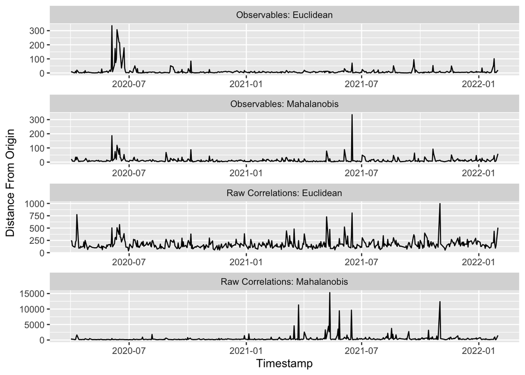

Reproduces anomaly detection tables in the article i.e. table 6, 7, 11, 12, 13, 14, 15, 16 depending on the date range and sampling time scale selected.

Anomaly Detection Results

| metric | features | subset_size | proportion_top | proportion_bottom | p_value | odds_ratio |
| --- | --- | --- | --- | --- | --- | --- |
| Euclidean | Observables | 25 | 0.40 | 0.20 | 10.83 | 2.67 |
| Euclidean | Observables | 50 | 0.38 | 0.24 | 9.71 | 1.94 |
| Euclidean | Observables | 100 | 0.38 | 0.28 | 8.79 | 1.58 |
| Mahalanobis | Observables | 25 | 0.44 | 0.16 | 3.11 | 4.12 |
| Mahalanobis | Observables | 50 | 0.38 | 0.16 | 1.16 | 3.22 |
| Mahalanobis | Observables | 100 | 0.39 | 0.13 | 0.00 | 4.28 |
| Euclidean | Raw Correlations | 25 | 0.52 | 0.32 | 12.58 | 2.30 |
| Euclidean | Raw Correlations | 50 | 0.44 | 0.28 | 7.21 | 2.02 |
| Euclidean | Raw Correlations | 100 | 0.39 | 0.22 | 0.68 | 2.27 |
| Mahalanobis | Raw Correlations | 25 | 0.24 | 0.16 | 36.26 | 1.66 |
| Mahalanobis | Raw Correlations | 50 | 0.32 | 0.14 | 2.79 | 2.89 |
| Mahalanobis | Raw Correlations | 100 | 0.28 | 0.20 | 12.32 | 1.56 |

# Visual Similarity

Top 10 Closest dates

| Distance | first_date | second_date |
| --- | --- | --- |
| 0.5 | 2021-04-08 | 2021-10-14 |
| 0.5 | 2021-04-14 | 2021-04-30 |
| 0.6 | 2020-04-14 | 2020-05-04 |
| 0.6 | 2021-04-26 | 2021-10-14 |
| 0.6 | 2021-05-17 | 2021-06-30 |
| 0.8 | 2021-03-11 | 2021-03-15 |
| 0.8 | 2020-04-22 | 2020-10-19 |
| 0.8 | 2021-04-29 | 2021-10-20 |
| 0.8 | 2020-05-22 | 2020-05-26 |
| 0.8 | 2020-11-30 | 2021-04-19 |

Top 10 Furthest dates

| Distance | first_date | second_date |
| --- | --- | --- |
| 328.3668 | 2020-06-04 | 2021-06-16 |
| 280.7757 | 2020-06-12 | 2021-06-16 |
| 260.9949 | 2020-06-23 | 2021-06-16 |
| 251.8205 | 2021-06-16 | 2021-08-20 |
| 251.7664 | 2020-06-15 | 2021-06-16 |
| 250.0257 | 2021-06-16 | 2021-08-27 |
| 249.5465 | 2020-06-09 | 2021-06-16 |
| 249.1193 | 2021-06-16 | 2021-10-22 |
| 245.1085 | 2020-06-16 | 2021-06-16 |
| 244.1544 | 2021-06-16 | 2022-01-31 |

Reproduces figure 5 in the article with date range set to 2020-04-01 to 2022-01-31 (time_range_type = “in-sample”) and time_scale = “5 minutes”.

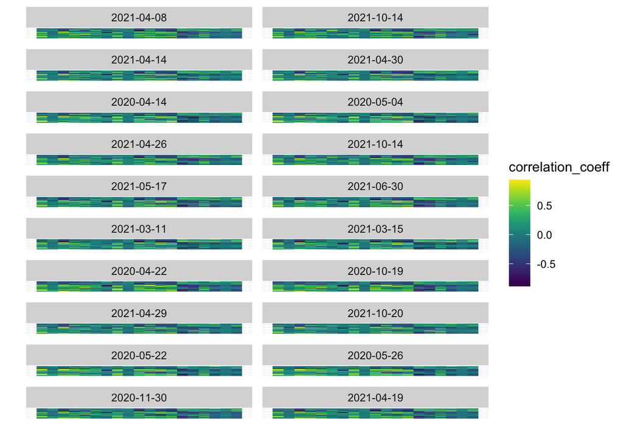

Reproduces figure 6 in the article with date range set to 2020-04-01 to 2022-01-31 (time_range_type = “in-sample”) and time_scale = “5 minutes”.

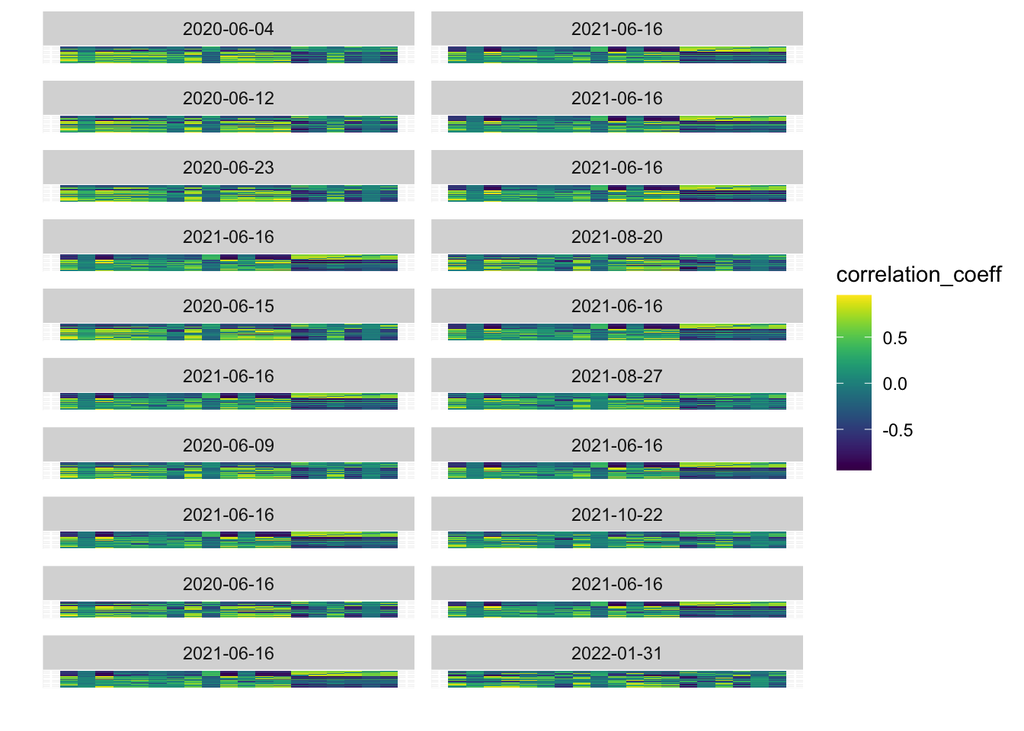

Calculates Spearman correlation between visual ordering proxy and observables with Mahalanobis distance metric.

```
## [1] 0.7
```

```
##
##  Spearman's rank correlation rho
##
## data:  pair_dist_perm_enh$dist.x and pair_dist_perm_enh$dist.y
## S = 5.0762e+13, p-value < 2.2e-16
## alternative hypothesis: true rho is greater than 0
## sample estimates:
##       rho
## 0.6883297
```